# Starbucks Capstone Challenge: Recommendation Engine

This data set contains simulated data that mimics customer behavior on the Starbucks rewards mobile app. Once every few days, Starbucks sends out an offer to users of the mobile app. An offer can be merely an advertisement for a drink or an actual offer such as a discount or BOGO (buy one get one free). Some users might not receive any offer during certain weeks.

In this section we build a recommendation engine for our customers. Our features are:

- person(int): the customer's id
- offer_id(int): the offer id
- offer received (int): if offer was received
- offer viewed(int): if the offer was viewed
- offer completed(int): if the offer was completed
- transaction(int): the number of transactions
- reward_infl(float): total reward from offers
- amount_infl(float): total amount spent because of offer
- email(int): emails received for offer
- mobile(int): mobile received for offer
- social(int): social medial received for offer
- web(int): website showing offer
- bogo(int): buy one get one offer type
- discount(int): discount offer type
- informational(int): informational offer type
- avg_difficulty(float): average difficulty
- time_to_open(float): average time to open offer
- time_to_complete(float): average time to complete offer
- total_amount(float): total amount spent by user
- amount_pct(float): percentage of total spending for offers
- age(int): age of user
- gender(int): gender of user
- income(int): user income
- seen_ratio(float): ratio of offers seen to offers received
- completed_ratio(float): ratio of offers completed to offers received

# Import Libraries

```python
import pandas as pd
import numpy as np
import matplotlib.pyplot as plt
import seaborn as sns
from scipy import sparse

%matplotlib inline

from plot_help import plot_confusion_matrix , make_svd_hist_plot, make_svd_heatmap_plot
```

# Import Data

```python
transcript = pd.read_csv("data/full_transcript.csv", index_col=0)
transcript['offer_id'] = transcript['offer_id'].astype(int)
transcript.head()
```

|  | person | offer_id | offer received | offer viewed | offer completed | transaction | reward | amount | difficulty | email | mobile | social | web | bogo | discount | informational |
| --- | --- | --- | --- | --- | --- | --- | --- | --- | --- | --- | --- | --- | --- | --- | --- | --- |
| 0 | 0 | 4 | 1 | 1 | 1 | 3 | 3.0 | 7.54 | 7 | 1 | 1 | 1 | 1 | 0 | 1 | 0 |
| 1 | 0 | 7 | 2 | 2 | 1 | 2 | 2.0 | 2.63 | 10 | 2 | 2 | 2 | 2 | 0 | 1 | 0 |
| 2 | 0 | 8 | 1 | 1 | 0 | 0 | 0.0 | 0.00 | 10 | 1 | 1 | 0 | 1 | 0 | 1 | 0 |
| 3 | 0 | 9 | 1 | 1 | 0 | 1 | 0.0 | 0.35 | 20 | 1 | 0 | 0 | 1 | 0 | 1 | 0 |
| 4 | 1 | 0 | 1 | 0 | 0 | 0 | 0.0 | 0.00 | 0 | 1 | 1 | 0 | 1 | 0 | 0 | 1 |

```python
user_df = pd.read_csv("data/user_df.csv", index_col=1)
user_df = user_df.drop(columns=['Unnamed: 0'])

user_df.head()
```

| person | offer received | offer viewed | offer completed | transaction | reward_infl | amount_infl | email | mobile | social | web | ... | avg_difficulty | time_to_open | time_to_complete | total_amount | amount_pct | age | gender | income | seen_ratio | completed_ratio |
| --- | --- | --- | --- | --- | --- | --- | --- | --- | --- | --- | --- | --- | --- | --- | --- | --- | --- | --- | --- | --- | --- |
| 0 | 5 | 5 | 2 | 6 | 5.0 | 10.52 | 5 | 4 | 3 | 5 | ... | 12.0 | 0.083929 | 0.285714 | 20.40 | 0.515686 | NaN | 2 | NaN | 1.0 | 0.40 |
| 1 | 2 | 0 | 1 | 0 | 5.0 | 0.00 | 2 | 2 | 0 | 2 | ... | 2.0 | 1.000000 | 1.000000 | 77.01 | 0.000000 | 55.0 | 0 | 112000.0 | 0.0 | 0.50 |
| 2 | 2 | 2 | 0 | 0 | 0.0 | 0.00 | 2 | 2 | 1 | 1 | ... | 2.0 | 0.000000 | 1.000000 | 14.30 | 0.000000 | NaN | 2 | NaN | 1.0 | 0.00 |
| 3 | 4 | 4 | 3 | 3 | 20.0 | 69.28 | 4 | 4 | 3 | 2 | ... | 5.0 | 0.234127 | 0.785714 | 159.27 | 0.434985 | 75.0 | 0 | 100000.0 | 1.0 | 0.75 |
| 4 | 5 | 3 | 0 | 1 | 0.0 | 1.09 | 5 | 2 | 1 | 4 | ... | 7.0 | 0.012500 | 1.000000 | 4.65 | 0.234409 | NaN | 2 | NaN | 0.6 | 0.00 |

5 rows × 23 columns

```python
user_df.columns
```

```
Index(['offer received', 'offer viewed', 'offer completed', 'transaction',
       'reward_infl', 'amount_infl', 'email', 'mobile', 'social', 'web',
       'bogo', 'discount', 'informational', 'avg_difficulty', 'time_to_open',
       'time_to_complete', 'total_amount', 'amount_pct', 'age', 'gender',
       'income', 'seen_ratio', 'completed_ratio'],
      dtype='object')
```

# Most Popular

The [most popular coffee drink in america](https://squareup.com/townsquare/coffee-day-2018) is the latte, with Americans drinking more than 67,000,000 lattes between June 2017 and June 2018. Therefore do we always suggest a latte?

Similarily, do we always present customers with the most popular offer?

The first method of recommendation is to propose the most popular offer. Here we can quantify the most popular offer as:

- The one that is the most viewed
- The one that returns the highest amount per view

In case of a tie, we pick the condition from other "popular" criteria. For example two offers with same view ratios are then ranked by income generated per view.

This approach is particularly useful for new users who we know little about, however it is a rigid method as it does not take into account user preferences. In general it is a good way to start and appeal to the masses.

```python
transcript_offerid_sum = transcript.groupby(by='offer_id', as_index=False).sum()
transcript_offerid_sum = transcript_offerid_sum[['offer_id', 'offer received','offer viewed', 'amount']]
transcript_offerid_sum['view_ratio'] = transcript_offerid_sum['offer viewed'] / transcript_offerid_sum['offer received']
transcript_offerid_sum['amount_per_view'] = transcript_offerid_sum['amount'] / transcript_offerid_sum['offer viewed']

transcript_offerid_sum
```

|  | offer_id | offer received | offer viewed | amount | view_ratio | amount_per_view |
| --- | --- | --- | --- | --- | --- | --- |
| 0 | 0 | 7617 | 4144 | 39591.26 | 0.544046 | 9.553875 |
| 1 | 1 | 7618 | 6687 | 54291.40 | 0.877789 | 8.118947 |
| 2 | 2 | 7677 | 4171 | 26874.43 | 0.543311 | 6.443162 |
| 3 | 3 | 7571 | 7264 | 55226.14 | 0.959451 | 7.602718 |
| 4 | 4 | 7646 | 7337 | 54806.01 | 0.959587 | 7.469812 |
| 5 | 5 | 7658 | 6716 | 58728.75 | 0.876991 | 8.744602 |
| 6 | 6 | 7593 | 7298 | 58246.78 | 0.961148 | 7.981198 |
| 7 | 7 | 7597 | 7327 | 63546.65 | 0.964460 | 8.672943 |
| 8 | 8 | 7632 | 4118 | 31817.55 | 0.539570 | 7.726457 |
| 9 | 9 | 7668 | 2663 | 26772.21 | 0.347287 | 10.053402 |

```python
def most_viewed_offer (transcript_offerid_sum, top_k=5):
    """
    Returns the top k most popular offer ids
    Inputs:
    -transcript_offerid_sum(pandas): dataframe with offer id & view ratio
    -topk(int): number of predictions
    """

    top_k_max = len(transcript_offerid_sum['offer_id'].unique())

    if top_k > top_k_max:
        print("can't return more items than unique offer id")
        print("function will return None")
        return None

    sorted_transcript = transcript_offerid_sum.sort_values(by=['view_ratio', 'amount_per_view'])

    top_offers = sorted_transcript['offer_id'].tolist()[:top_k]

    print("The top {} offers are".format(top_k))
    for offer in top_offers:
        print(offer)

    return top_offers
```

```python
#Sample output
most_viewed_offer(transcript_offerid_sum, top_k=3)
```

[output not shown]

```
[9, 8, 2]
```

```python
def most_profit_offer (transcript_offerid_sum, top_k=5):
    """
    Returns the top k most profitable offer ids
    Inputs:
    -transcript_offerid_sum(pandas): dataframe with offer id & view ratio
    -topk(int): number of predictions
    """

    top_k_max = len(transcript_offerid_sum['offer_id'].unique())

    if top_k > top_k_max:
        print("can't return more items than unique offer id")
        print("function will return None")
        return None

    sorted_transcript = transcript_offerid_sum.sort_values(by=['amount_per_view', 'view_ratio'])

    top_offers = sorted_transcript['offer_id'].tolist()[:top_k]

    print("The top {} offers are".format(top_k))
    for offer in top_offers:
        print(offer)

    return top_offers
```

```python
#sample output
most_profit_offer (transcript_offerid_sum, top_k=3)
```

[output not shown]

```
[2, 4, 3]
```

# Collaborative Filtering: User-User Similarity

In this section we suggest items to user based on their similarity to other users. This technique called [collaborative filtering](https://en.wikipedia.org/wiki/Collaborative_filtering) can use [cosine similarity](https://en.wikipedia.org/wiki/Cosine_similarity), [Pearson correlaction](https://en.wikipedia.org/wiki/Pearson_correlation_coefficient), or [Euclidian distance](https://en.wikipedia.org/wiki/Pearson_correlation_coefficient) to determine the similarity of two users.

Users whose vectors have a small angle between them will have a high cosine value. Recall that cos(0)=1 and that cosine varies between -1 and 1. Pearson's correlation also varies between those values. For the two methods, the closer the output to 1 the more similar two users(vectors) are

If we have two vectors x and y, we can compare their individual elements in the following way to calculate Pearson's correlation coefficient:

$$CORR(\textbf{x}, \textbf{y}) = \frac{\sum\limits_{i=1}^{n}(x_i - \bar{x})(y_i - \bar{y})}{\sqrt{\sum\limits_{i=1}^{n}(x_i-\bar{x})^2}\sqrt{\sum\limits_{i=1}^{n}(y_i-\bar{y})^2}} $$

where

$$\bar{x} = \frac{1}{n}\sum\limits_{i=1}^{n}x_i$$

A key mathematical property of Pearson's correlation coefficient:

*It is invariant under separate changes in location and scale in the two variables. That is, we may transform X to a + bX and transform Y to c + dY, where a, b, c, and d are constants with b, d > 0, without changing the correlation coefficient. (This holds for both the population and sample Pearson correlation coefficients.)*

Note also that if the attribute vectors are normalized by subtracting the vector means, the measure is called the centered cosine similarity and is equivalent to the Pearson correlation coefficient. For a more detailed explanation, refer to this [post](https://www.researchgate.net/post/Can_someone_differentiate_between_Cosine_Adjusted_cosine_and_Pearson_correlation_similarity_measuring_techniques).

Euclidian distiance as a metric means looking at the closest similar node, which can be expressed in the sum of squared distiances.

For two vectors **x** and **y**, we can compute this as:

$$ EUC(\textbf{x}, \textbf{y}) = \sqrt{\sum\limits_{i=1}^{n}(x_i - y_i)^2}$$

The principal assumption behind collaborative filtering is that users who are similar by some metrics will have the same tastes. In this notebook we will explore Pearson correlation and euclidian distance.

As a default method of computing similarity, we will prefer Pearson's correlation since it is invariant to scaling

```python
user_views = transcript[['person', 'offer_id', 'offer viewed']]
#shuffle the entries
user_views = user_views.sample(frac=1)

user_views.head()
```

|  | person | offer_id | offer viewed |
| --- | --- | --- | --- |
| 51947 | 13928 | 7 | 1 |
| 39306 | 10539 | 7 | 1 |
| 31320 | 8403 | 6 | 1 |
| 34505 | 9252 | 4 | 1 |
| 53434 | 14339 | 1 | 1 |

```python
# Create user-by-item matrix
user_by_item = user_views.groupby(['person', 'offer_id'])['offer viewed'].max().unstack()
#replace seen 0 by nan
user_by_item = user_by_item.replace(to_replace=0, value=np.nan)

user_by_item.head()
```

| offer_id person | 0 | 1 | 2 | 3 | 4 | 5 | 6 | 7 | 8 | 9 |
| --- | --- | --- | --- | --- | --- | --- | --- | --- | --- | --- |
| 0 | NaN | NaN | NaN | NaN | 1.0 | NaN | NaN | 2.0 | 1.0 | 1.0 |
| 1 | NaN | NaN | NaN | NaN | NaN | NaN | NaN | NaN | NaN | NaN |
| 2 | NaN | 1.0 | 1.0 | NaN | NaN | NaN | NaN | NaN | NaN | NaN |
| 3 | NaN | 1.0 | 1.0 | 1.0 | NaN | 1.0 | NaN | NaN | NaN | NaN |
| 4 | 1.0 | NaN | NaN | NaN | NaN | NaN | NaN | NaN | NaN | 2.0 |

```python
user_by_item.shape
```

```
(16994, 10)
```

### Record Offers Seen For Each User

```python
def get_offers_seen(user_by_item, user):
    """
    Get the offers seen by a user, sort by most viewed first
    Inputs:
    - user_by_user(pandas): user item matrix with user as index and offer id as column
    - user(int): the user id

    Output:
    - offers_seen(list): an array of offers seen
    """

    #get seen offers
    user_offers_seen = user_by_item.loc[user][user_by_item.loc[user].isna()==False]

    #sort by descending order
    user_offers_seen = user_offers_seen.sort_values(ascending=False)

    #get values
    user_offers_seen = user_offers_seen.index.values.tolist()

    return user_offers_seen
```

```python
def create_user_offer_dict(user_by_item):
    """
    Input:
    - user_by_user(pandas): user item matrix with user as index and offer id as column
    Output:
    offers_seen(dict): user ID as key and offers viewed as values
    """

    #dict key is user and values are offers seen
    offers_seen = dict()

    #for each user get the offers seen
    for user in user_by_item.index:
        offers_seen[user] = get_offers_seen(user_by_item, user)

    return offers_seen
```

```python
#get a dict of seen offers
offers_seen_dict = create_user_offer_dict(user_by_item)
```

```python
#get sample output
offers_seen_dict[0]
```

```
[7, 9, 8, 4]
```

### Measure Similarity

```python
def compute_similarity_euclid(user1_id, user2_id,user_df=user_df):
    """
    Compute the euclidian distance between two users
    Inputs:
    - user1(int): fist user id
    - user2(int): second user id
    - user_df(pandas): features about users
    Output:
    - norm(numpy.float64): norm between two users
    """
    #get user rows
    user1 = user_df.loc[user1_id]
    user2 = user_df.loc[user2_id]

    #ge the difference
    diff = user1 - user2

    #drop nans
    diff= diff.dropna()

    #calculate the norm
    norm = np.linalg.norm(diff)

    return norm
```

```python
def compute_similarity_pearson(user1_id, user2_id,user_df=user_df):
    """
    Compute the pearson correlation  between two users
    Inputs:
    - user1(int): fist user id
    - user2(int): second user id
    - user_df(pandas): features about users
    Output:
    - corr(numpy.float64): correlation
    """

    #make dataframe from user ids
    df_corr = user_df.loc[[user1_id, user2_id]]

    #get correlation and select term off the diagonal
    corr = df_corr.transpose().corr().iloc[0,1]

    return corr
```

```python
def find_most_similar(user, user_df=user_df, method='pearson'):
    """
    Find the most similar users to a given user id
    Inputs:
    - user(int): user idx
    - user_df(pandas): features about users
    - method(str): method to get similarity (pearson, euclid)
    Output:
    - most_sim_users(np.array): sorted list of most similar users
    """

    #store similarities here
    sim_list= []


    if method =='pearson':
        for idx in user_df.index:
            sim = compute_similarity_pearson(user, idx)
            sim_list.append(sim)
        #convert to numpy array
        sim_list= np.array(sim_list)

        #get ids sorted in DESCENDING order for PEARSON
        most_sim_users = sim_list.argsort()[::-1]
        #drop the first user
        most_sim_users = most_sim_users[1:]

    if method =='euclid':
        for idx in user_df.index:
            sim = compute_similarity_euclid(user, idx)
            sim_list.append(sim)
        #convert to numpy array
        sim_list= np.array(sim_list)

        #get ids sorted in ASCENDING order for EUCLIDIAN
        most_sim_users = sim_list.argsort()
        #drop the first user
        most_sim_users = most_sim_users[1:]


    return most_sim_users
```

### Make Recommendation by Similarity

```python
def make_collab_recomm(user, offers_seen_dict = offers_seen_dict,
                       top_k = 2, user_by_item = user_by_item,
                       user_df = user_df, method='pearson', verbose=True):

    """
    Make offer recommendations for a user
    Inputs:
    - user(int): user idx
    - offers_seen_dict(dict): user idx as key and offers seen as values
    - top_k(int): number of recommendations to make
    - user_by_item(pandas): user item dataframe with users as rows, offers as columns, and times seen as values
    - user_df(pandas): features about users
    - method(str): method to get similarity (pearson, euclid)
    Output:
    - offers_to_user(list): array of offers for user

    """

    #find the most similar users
    sim_to_user = find_most_similar(user, user_df, method)

    #get offers seen
    idx_seen = offers_seen_dict[user]

    if verbose:
        print("Similarity measured by {}".format(method))
        print("Original user {} already saw: \t {}".format(user, idx_seen))

    #get number of offers already seen
    idx_seen_len = len(idx_seen)

    #get number of offers available
    len_available = user_by_item.shape[1]

    if top_k > (len_available - idx_seen_len):
        print("Top k of {} is bigger than possible, will return only {} offers".format(top_k, (len_available - idx_seen_len)))
        top_k = (len_available - idx_seen_len)

    #empty set to store unique offer ids
    proposed_offers = np.array([])

    for idx in sim_to_user:
        idx_sim_offer = offers_seen_dict[idx]

        new_offers = (np.setdiff1d(idx_sim_offer,idx_seen))

        if verbose:
            print("Similar user {} saw: \t {}".format(idx, idx_sim_offer))
            print("Unseen offers by original user: \t {}".format(new_offers))

        proposed_offers = np.unique(np.concatenate([new_offers, proposed_offers], axis=0))


        if len(proposed_offers)>top_k:
            break

    proposed_offers = proposed_offers[0:top_k]

    if verbose:
        print("\nFor user {} we suggest offers : \t {}".format(user, proposed_offers))

    return proposed_offers
```

```python
#get sample output with pearson
make_collab_recomm(5, top_k=3, verbose=True)
```

```
Similarity measured by pearson
Original user 5 already saw: 	 [8, 7, 2]
Similar user 6534 saw: 	 [0, 8, 6, 3]
Unseen offers by original user: 	 [0 3 6]
Similar user 1307 saw: 	 [3, 7, 6]
Unseen offers by original user: 	 [3 6]
Similar user 98 saw: 	 [5]
Unseen offers by original user: 	 [5]

For user 5 we suggest offers : 	 [0. 3. 5.]
```

```
array([0., 3., 5.])
```

```python
#sample output for euclidian distance
make_collab_recomm(5, top_k=3, method='euclid',verbose=True)
```

```
Similarity measured by euclid
Original user 5 already saw: 	 [8, 7, 2]
Similar user 440 saw: 	 [6, 3]
Unseen offers by original user: 	 [3 6]
Similar user 3669 saw: 	 [8, 3]
Unseen offers by original user: 	 [3]
Similar user 11609 saw: 	 [6, 3]
Unseen offers by original user: 	 [3 6]
Similar user 12411 saw: 	 [6, 1]
Unseen offers by original user: 	 [1 6]
Similar user 10 saw: 	 [4, 5]
Unseen offers by original user: 	 [4 5]

For user 5 we suggest offers : 	 [1. 3. 4.]
```

```
array([1., 3., 4.])
```

# Matrix Factorization

This section covers matrix factorization), in patticular FunkSVD application to [singular value decomposition](https://en.wikipedia.org/wiki/Singular_value_decomposition). We will user how we can decompose our user item matrix into latent features to help us make better recommendations.

Our user-item matrix has users for rows and offer_id for the columns. SVD decomposes the user item matrix into matrices that have the following dimensions:

$$ U_{n x k} $$$$\Sigma_{k x k} $$$$V^T_{k x m} $$

where:

1. n is the number of users
2. k is the number of latent features to keep
3. m is the number of items

```python
#convert user item matrix to numpy
ratings_mat = np.array(user_by_item)
```

## FunkSVD

```python
def FunkSVD(ratings_mat, latent_features=4, learning_rate=0.0001, iters=100, print_every=50):
    '''
    This function performs matrix factorization using a basic form of FunkSVD with no regularization

    INPUT:
    - user_by_item(df): user item dataframe with users as rows, offers as columns, and times seen as values
    - latent_features: (int) the number of latent features used
    - learning_rate: (float) the learning rate
    - iters: (int) the number of iterations

    OUTPUT:
    - user_mat(numpy.array): a user by latent feature matrix
    - item_mat(numpy.array) a latent feature by item matrix
    '''


    # Set up useful values to be used through the rest of the function
    n_users = ratings_mat.shape[0]
    n_items = ratings_mat.shape[1]
    num_ratings = np.count_nonzero(~np.isnan(ratings_mat))

    # initialize the user and item matrices with random values
    user_mat = np.random.rand(n_users, latent_features)
    item_mat = np.random.rand(latent_features, n_items)

    # initialize sse at 0 for first iteration
    sse_accum = 0

    # header for running results
    print("Optimizaiton Statistics")
    print("Iterations | Mean Squared Error ")

    # for each iteration
    for iteration in range(iters):

        # update our sse
        old_sse = sse_accum
        sse_accum = 0

        # For each user-item pair
        for i in range(n_users):
            for j in range(n_items):

                # if the rating exists
                if ratings_mat[i, j] > 0:

                    # compute the error as the actual minus the dot product of the user and item latent features
                    diff = ratings_mat[i, j] - np.dot(user_mat[i, :], item_mat[:, j])

                    # Keep track of the sum of squared errors for the matrix
                    sse_accum += diff**2

                    # update the values in each matrix in the direction of the gradient
                    for k in range(latent_features):
                        user_mat[i, k] += learning_rate * (2*diff*item_mat[k, j])
                        item_mat[k, j] += learning_rate * (2*diff*user_mat[i, k])

        # print results for iteration
        if iteration % print_every ==0:
            print("%d \t\t %f" % (iteration, sse_accum / num_ratings))

    return user_mat, item_mat
```

## Split Data: Train and Validation

```python
def create_train_test(reviews, training_size, testing_size):
    '''
    INPUT:
    - reviews(pandas df): dataframe to split into train and test
    - order_by(string): column name to sort by
    - training_size(int): number of rows in training set
    - testing_size(int): number of columns in the test set

    OUTPUT:
    - training_df(pandas df): dataframe of the training set
    - validation_df(pandas df): dataframe of the test set
    '''
    reviews_new = reviews.copy()
    training_df = reviews_new.head(training_size)
    validation_df = reviews_new.iloc[training_size:training_size+testing_size]

    return training_df, validation_df
```

```python
#make train and valid sets from df below
user_views.head()
```

|  | person | offer_id | offer viewed |
| --- | --- | --- | --- |
| 51947 | 13928 | 7 | 1 |
| 39306 | 10539 | 7 | 1 |
| 31320 | 8403 | 6 | 1 |
| 34505 | 9252 | 4 | 1 |
| 53434 | 14339 | 1 | 1 |

```python
user_views.shape
```

```
(63288, 3)
```

```python
train_df, val_df = create_train_test(user_views, 55000, 5000)
```

```python
train_df.head()
```

|  | person | offer_id | offer viewed |
| --- | --- | --- | --- |
| 51947 | 13928 | 7 | 1 |
| 39306 | 10539 | 7 | 1 |
| 31320 | 8403 | 6 | 1 |
| 34505 | 9252 | 4 | 1 |
| 53434 | 14339 | 1 | 1 |

```python
val_df.head()
```

|  | person | offer_id | offer viewed |
| --- | --- | --- | --- |
| 6537 | 1761 | 6 | 2 |
| 30524 | 8187 | 5 | 1 |
| 17893 | 4811 | 0 | 1 |
| 3266 | 878 | 0 | 0 |
| 19031 | 5118 | 8 | 0 |

```python
# Create user-by-item matrix
train_user_item = train_df[['person', 'offer_id', 'offer viewed']]
train_data_df = train_user_item.groupby(['person', 'offer_id'])['offer viewed'].max().unstack()
train_data_np = np.array(train_data_df)

train_data_df.head()
```

| offer_id person | 0 | 1 | 2 | 3 | 4 | 5 | 6 | 7 | 8 | 9 |
| --- | --- | --- | --- | --- | --- | --- | --- | --- | --- | --- |
| 0 | NaN | NaN | NaN | NaN | 1.0 | NaN | NaN | 2.0 | 1.0 | 1.0 |
| 1 | 0.0 | NaN | 0.0 | NaN | NaN | NaN | NaN | NaN | NaN | NaN |
| 2 | NaN | 1.0 | NaN | NaN | NaN | NaN | NaN | NaN | NaN | NaN |
| 3 | NaN | 1.0 | 1.0 | 1.0 | NaN | NaN | NaN | NaN | NaN | NaN |
| 4 | 1.0 | 0.0 | NaN | NaN | NaN | NaN | NaN | NaN | NaN | 2.0 |

```python
# Fit FunkSVD with the specified hyper parameters to the training data
k = 15
lr = 0.005


user_mat, item_mat = FunkSVD(train_data_np, latent_features=k, learning_rate=lr, iters=200)
```

```
Optimizaiton Statistics
Iterations | Mean Squared Error
0 		 0.197997
50 		 0.115448
100 		 0.081391
150 		 0.039923
```

```python
def predict_rating(user_matrix, item_matrix, user_id, item_id, train_data_df = train_data_df):
    '''
    INPUT:
    - user_matrix(numpy.array): user by latent factor matrix
    - item_matrix(numpy.array): latent factor by item matrix
    - user_id(int): the user id
    - item(int): the item id according the  df
    - train_data_df(pandas):

    OUTPUT:
    - pred(int): the predicted rating for user_id-item_id according to FunkSVD
    '''
    # Use the training data to create a series of users and items that matches the ordering in training data
    user_ids_series = np.array(train_data_df.index)
    item_ids_series = np.array(train_data_df.columns)

    # User row and items Column
    user_row = np.where(user_ids_series == user_id)[0][0]
    item_col = np.where(item_ids_series == item_id)[0][0]

    # Take dot product of that row and column in U and V to make prediction
    pred = np.dot(user_matrix[user_row, :], item_matrix[:, item_col])

    #round because we are dealing with integers
    pred = round(pred)

    return pred
```

```python
#sample output
predict_rating(user_mat, item_mat, 2, 2)
```

```
1.0
```

```python
#more outputs
predict_rating(user_mat, item_mat, 2000, 9)
```

```
2.0
```

```python
def validation_comparison(val_df, user_mat=user_mat, item_mat=item_mat):
    '''
    INPUT:
    - val_df(pandas): the validation dataset created in the third cell above
    - user_mat(numpy.array): U matrix in FunkSVD
    - item_mat(numpy.array): V matrix in FunkSVD

    OUTPUT:
    - rmse(float) RMSE of how far off each value is from it's predicted value
    - perc_rated(float) percent of predictions out of all possible that could be rated
    - actual_v_pred(numpy.array) a 10 x 10 grid with counts for actual vs predicted values
    '''

    val_users = np.array(val_df['person'])
    val_items = np.array(val_df['offer_id'])
    val_ratings = np.array(val_df['offer viewed'])

    sse = 0
    num_rated = 0
    preds, acts = [], []
    actual_v_pred = np.zeros((10,10))
    for idx in range(len(val_users)):
        try:
            pred = predict_rating(user_mat, item_mat, val_users[idx], val_items[idx])
            sse += (val_ratings[idx] - pred)**2
            num_rated+=1
            preds.append(pred)
            acts.append(val_ratings[idx])
            actual_v_pred[11-int(val_ratings[idx]-1), int(round(pred)-1)]+=1

        except:
            continue

    rmse = np.sqrt(sse/num_rated)
    perc_rated = num_rated/len(val_users)
    return rmse, perc_rated, actual_v_pred, preds, acts
```

```python
rmse, perc_rated, actual_v_pred, preds, acts = validation_comparison(val_df)
```

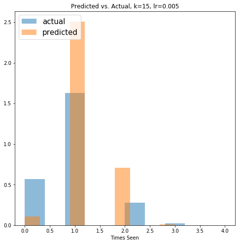

```python
make_svd_hist_plot(k, lr, acts, preds)
```

```
Confusion matrix, without normalization
Confusion Matrix:
[[  33  890  200    2    0]
 [ 109 2377  716   10    0]
 [  17  400  123    1    0]
 [   2   38    6    0    0]
 [   0    3    0    0    0]]
Plotted confusion matrix
```

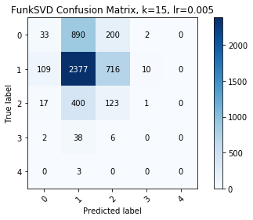

```python
plot_confusion_matrix(acts, preds, title="FunkSVD Confusion Matrix, k={}, lr={}".format(k,lr),normalize=False)
```

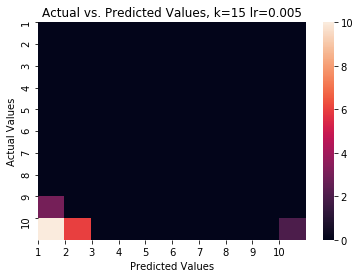

```python
make_svd_heatmap_plot(k, lr, actual_v_pred)
```

## Optimize

The number of latent features plays a role in the accuracy of our predictions. Therefore we can further optmize our results with hyperparamter tuning. We will create a grid of latent feature sizes and compare the root mean square error for each.

Additionally we can also vary the learning rate and create a [grid search](https://en.wikipedia.org/wiki/Hyperparameter_optimization#Grid_search).

```
Evaluation for k=15 and lr=0.005
Optimizaiton Statistics
Iterations | Mean Squared Error
0 		 0.192400
50 		 0.115189
100 		 0.079835
150 		 0.037327
Confusion matrix, without normalization
Confusion Matrix:
[[  25  901  198    1    0]
 [ 126 2432  647    7    0]
 [  19  415  107    0    0]
 [   1   33   12    0    0]
 [   0    3    0    0    0]]
Plotted confusion matrix
```

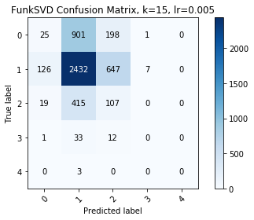

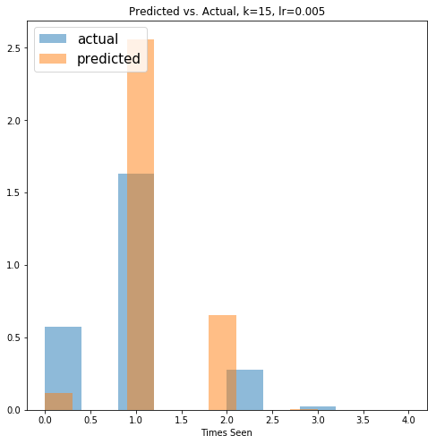

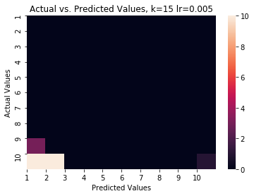

```
Evaluation for k=20 and lr=0.005
Optimizaiton Statistics
Iterations | Mean Squared Error
0 		 0.204908
50 		 0.119707
100 		 0.078583
150 		 0.031238
Confusion matrix, without normalization
Confusion Matrix:
[[  35  892  197    1    0]
 [ 121 2387  702    2    0]
 [  17  398  126    0    0]
 [   2   30   14    0    0]
 [   1    0    2    0    0]]
Plotted confusion matrix
```

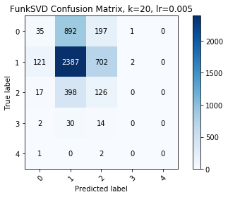

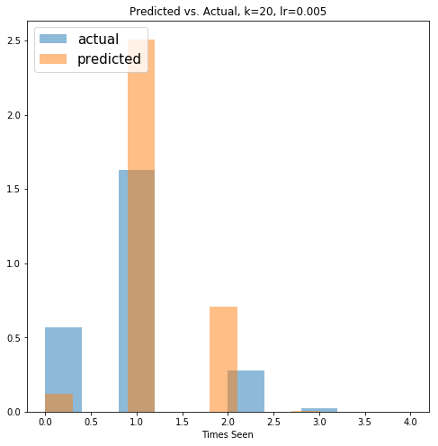

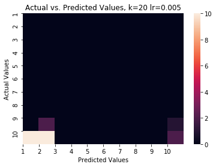

```
Evaluation for k=25 and lr=0.005
Optimizaiton Statistics
Iterations | Mean Squared Error
0 		 0.224527
50 		 0.123279
100 		 0.080301
150 		 0.029403
Confusion matrix, without normalization
Confusion Matrix:
[[  47  901  177    0    0]
 [ 130 2374  706    2    0]
 [  29  394  118    0    0]
 [   2   32   11    1    0]
 [   0    2    1    0    0]]
Plotted confusion matrix
```

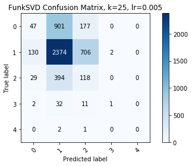

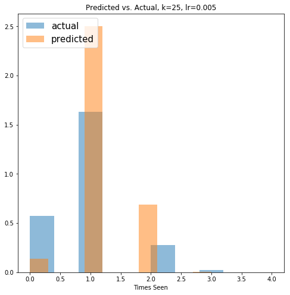

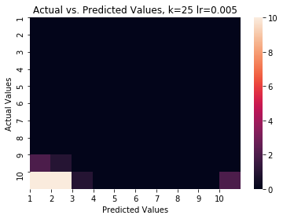

```
Evaluation for k=15 and lr=0.008
Optimizaiton Statistics
Iterations | Mean Squared Error
0 		 0.187960
50 		 0.093907
100 		 0.029551
150 		 0.004930
Confusion matrix, without normalization
Confusion Matrix:
[[  53  853  218    1    0]
 [ 181 2351  676    4    0]
 [  31  392  116    2    0]
 [   1   33   12    0    0]
 [   0    1    2    0    0]]
Plotted confusion matrix
```

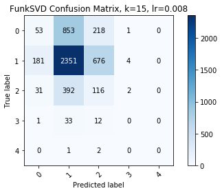

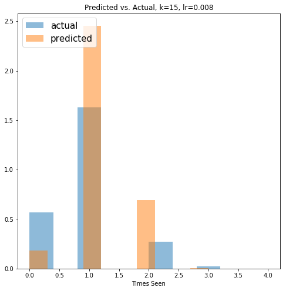

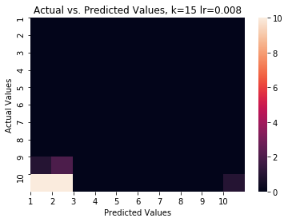

```
Evaluation for k=20 and lr=0.008
Optimizaiton Statistics
Iterations | Mean Squared Error
0 		 0.195141
50 		 0.097433
100 		 0.023614
150 		 0.003240
Confusion matrix, without normalization
Confusion Matrix:
[[  59  870  193    3    0]
 [ 166 2335  708    3    0]
 [  25  380  135    1    0]
 [   1   37    8    0    0]
 [   0    2    1    0    0]]
Plotted confusion matrix
```

[6 more figures not shown]

```
best_k = 	25
best_lr= 	0.005
best_rmse =  	0.7986
```

```python
#create grid
k_grid = [15, 20, 25]
lr_grid = [0.005, 0.008]

#placeholder value
best_k =0
best_lr=0
best_rmse = np.inf
best_perc_rated = None
best_user_mat= None
best_item_mat = None
best_actual_v_pred = None
best_preds = None
best_acts = None

for lr in lr_grid:
    for k in k_grid:
        print("Evaluation for k={} and lr={}".format(k, lr))

        user_mat_test, item_mat_test = FunkSVD(train_data_np, latent_features=k, learning_rate=lr, iters=200)
        rmse, perc_rated, actual_v_pred, preds, acts = validation_comparison(val_df, user_mat_test, item_mat_test)

        #record with plots
        title = 'FunkSVD Confusion Matrix, k={}, lr={}'.format(k, lr)
        save_path = "plots/svd_cm_"+"lr"+str(best_lr)+"_k"+str(best_k)+".png"
        plot_confusion_matrix(acts, preds, normalize=False, title=title, saveloc = save_path)

        make_svd_hist_plot(k, lr, acts, preds)
        make_svd_heatmap_plot(k, lr, actual_v_pred)


        #update params if improved
        if rmse < best_rmse:
            #update score
            best_rmse = rmse
            #update params
            best_k = k
            best_lr=lr

            #store best results
            best_perc_rated = perc_rated
            best_user_mat= user_mat_test
            best_item_mat = item_mat_test
            best_actual_v_pred = actual_v_pred
            best_preds = preds
            best_acts = acts

print("\n")
print("best_k = \t{}".format(best_k))
print("best_lr= \t{}".format(best_lr))
print("best_rmse =  \t{:.4f}".format(best_rmse))
```